# Diversity analysis

# county analysis

Regress difference in diversity (four-group entropy) on percent population change using piecewise regression. Enter separate variables for percent population loss just for pop. loss counties, i.e., variable is coded 0 where percent pop loss >= 0 and given the actual percent population loss when less than 0. I multiplied this variable by -1 so that positive coefficients for this variable would be interpreted as the effect for a one-percent increase in population *loss*. All county-level models include state-level fixed effects. Sample includes only counties in the contiguous US, excluding DC. See Glaeser’s “Durable Housing” paper for similar use of piecewise pop loss and pop gain variables.

## ols model

```r
# load data
df_cty <- read.csv(file = "/home/eric/Documents/franklin/narsc2018/generated_data/county_regression_data.csv",
               header = TRUE, sep = ",")

df_cty$STATE <- factor(df_cty$STATE)
df_cty$region <- factor(df_cty$region)
```

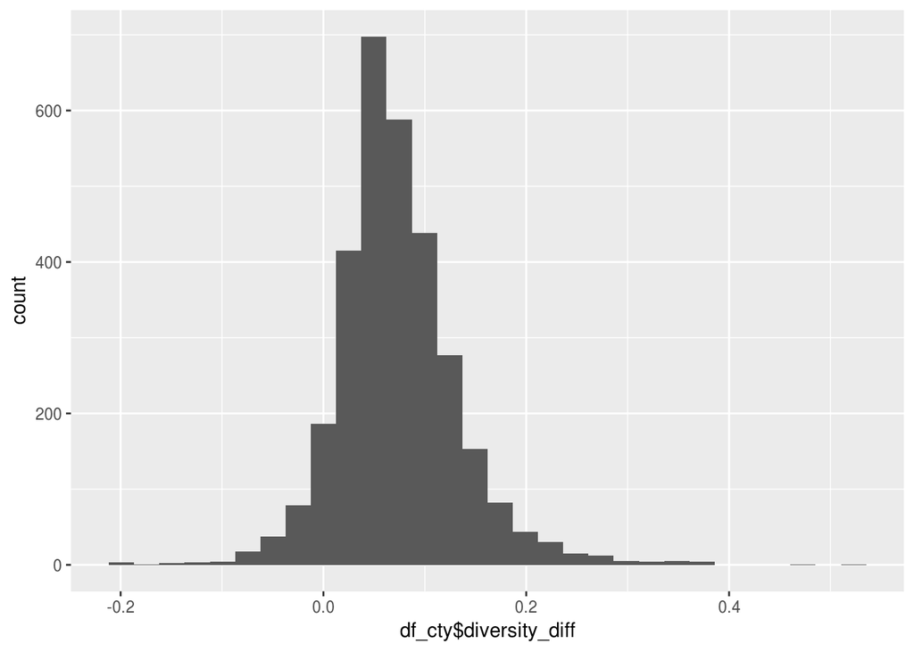

```r
# plot histogram from difference in diversity
qplot(df_cty$diversity_diff, geom = "histogram")
```

```r
# Run model: OLS diff in diversity 2000 to 2010
# include pop loss and pop gain piecewise
cty_ols_pwise <- lm(diversity_diff ~ pop_loss + pop_gain + pwhite_00 + log(pop00) + STATE , data = df_cty)
```

```r
# Adjust standard errors
# coeftest(cty_ols_pwise, vcov = vcovHC(cty_ols_pwise, "HC1"))

cov1 <- vcovHC(cty_ols_pwise, type = "HC1")
robust_se1 <- sqrt(diag(cov1))

# report default and robust standard errors
stargazer(cty_ols_pwise, cty_ols_pwise, se=list(NULL, robust_se1),
          omit = "STATE", notes = c("State fixed effects omitted"),
          column.labels = c("default", "robust"), align = TRUE, single.row = TRUE,
          type="text")
```

```
##
## ===================================================================
##                                         Dependent variable:
##                                 -----------------------------------
##                                           diversity_diff
##                                      default           robust
##                                        (1)               (2)
## -------------------------------------------------------------------
## pop_loss                        -0.001** (0.0003)  -0.001 (0.0004)
## pop_gain                        0.001*** (0.0001) 0.001*** (0.0002)
## pwhite_00                       0.105*** (0.007)  0.105*** (0.009)
## log(pop00)                      0.013*** (0.001)  0.013*** (0.001)
## Constant                        -0.145*** (0.013) -0.145*** (0.018)
## -------------------------------------------------------------------
## Observations                          3,105             3,105
## R2                                    0.325             0.325
## Adjusted R2                           0.313             0.313
## Residual Std. Error (df = 3053)       0.050             0.050
## F Statistic (df = 51; 3053)         28.761***         28.761***
## ===================================================================
## Note:                                   *p<0.1; **p<0.05; ***p<0.01
##                                         State fixed effects omitted
```

Pop loss in these models is not associated with county differences in diversity scores, while pop. gain is positively associated with change in diversity.

## county logit model

Predict loss of diversity as binary outcome. Code counties as 1 where difference < 0 and 0 otherwise.

```r
cty_logit_pwise <- glm(formula = diversity_decline ~ pop_loss + pop_gain + pwhite_00 + log(pop00) + STATE,
              data = df_cty, family = "binomial")

# summary(cty_logit_pwise)

cov1 <- vcovHC(cty_logit_pwise, type = "HC1")
robust_se1 <- sqrt(diag(cov1))
#
# report default and robust standard errors
stargazer(cty_logit_pwise, cty_logit_pwise, se=list(NULL, robust_se1),
          omit = "STATE", notes = c("State fixed effects omitted", "Coeffs are untransformed logits"),
          column.labels = c("default", "robust"), align = TRUE, single.row = TRUE,
          type="text")
```

```
##
## =====================================================
##                           Dependent variable:
##                   -----------------------------------
##                            diversity_decline
##                        default           robust
##                          (1)               (2)
## -----------------------------------------------------
## pop_loss          0.071*** (0.018)  0.071*** (0.022)
## pop_gain            0.007 (0.010)     0.007 (0.009)
## pwhite_00         -6.484*** (0.512) -6.484*** (0.570)
## log(pop00)        -0.395*** (0.076) -0.395*** (0.083)
## Constant          4.805*** (1.032)  4.805*** (1.143)
## -----------------------------------------------------
## Observations            3,105             3,105
## Log Likelihood        -532.504          -532.504
## Akaike Inf. Crit.     1,169.008         1,169.008
## =====================================================
## Note:                     *p<0.1; **p<0.05; ***p<0.01
##                           State fixed effects omitted
##                       Coeffs are untransformed logits
```

Pop. loss is associated with greater odds of a decrease in diversity, while pop gain is not associated with the binary outcome of loss vs. gain.

# tract analysis

Include MSA fixed effects and dummy for outlying vs. central county.

```r
# load data
df_trt <- read.csv(file = "/home/eric/Documents/franklin/narsc2018/generated_data/tract_regression_data.csv",
               header = TRUE, sep = ",")
df_trt$CBSA_Title <- factor(df_trt$CBSA_Title)
df_trt$Central_Outlying_County <- factor(df_trt$Central_Outlying_County)
```

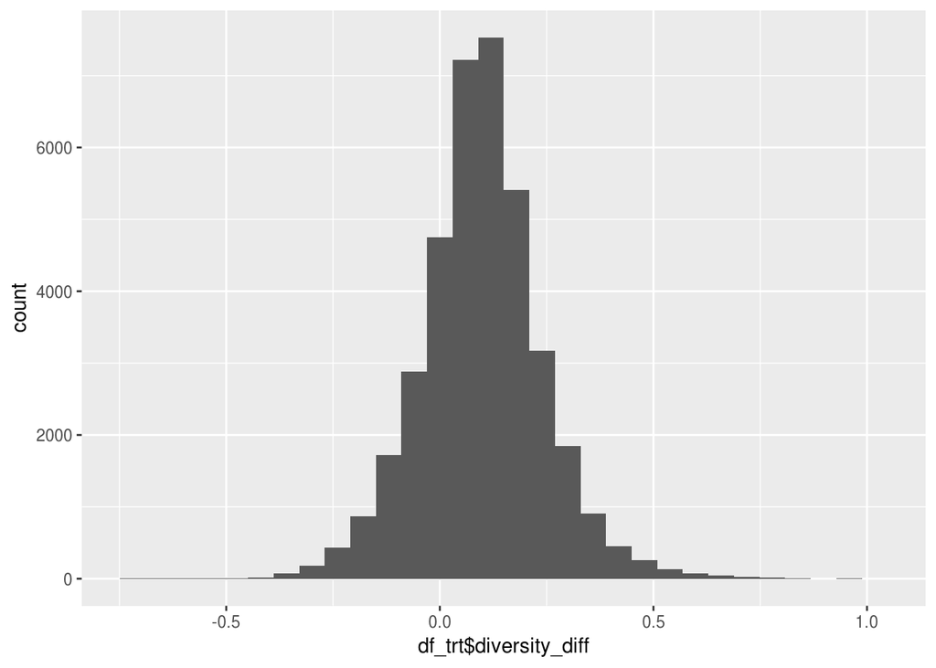

```r
# plot DV - difference in diversity
qplot(df_trt$diversity_diff, geom = "histogram")
```

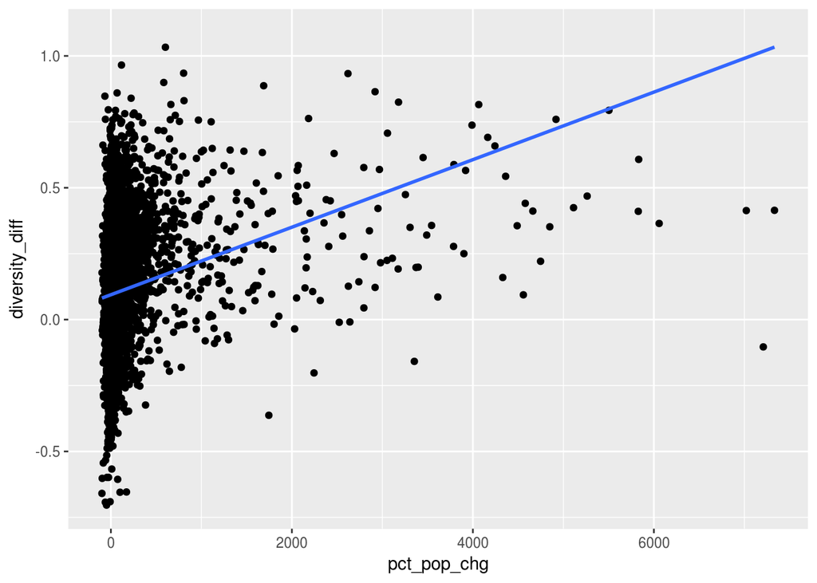

```r
# plot change in diversity against change in pop. for all tracts
df_trt %>%
  ggplot(aes(y = diversity_diff, x = pct_pop_chg)) +
  geom_point() +
  geom_smooth(method = "lm", fill = NA)
```

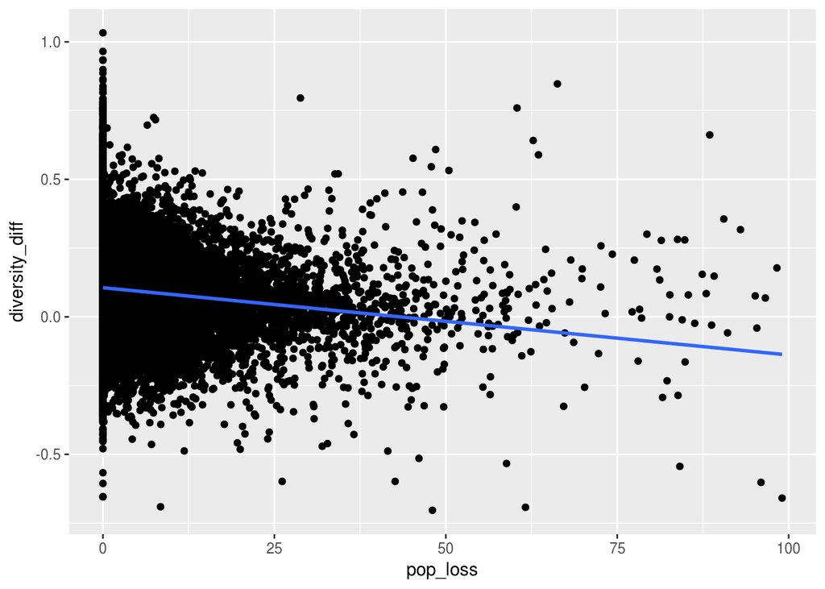

```r
# plot change in diversity against change in pop. for shrinking tracts
df_trt %>%
  ggplot(aes(y = diversity_diff, x = pop_loss)) +
  geom_point() +
  geom_smooth(method = "lm", fill = NA)
```

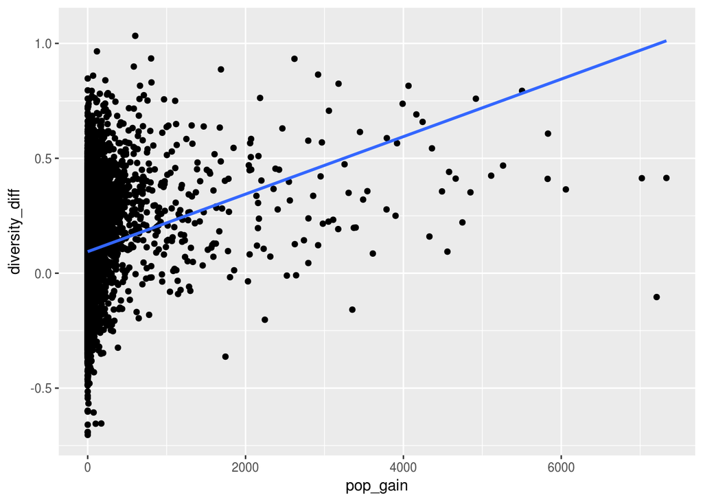

```r
# plot change in diversity against change in pop. for growing tracts
df_trt %>%
  ggplot(aes(y = diversity_diff, x = pop_gain)) +
  geom_point() +
  geom_smooth(method = "lm", fill = NA)
```

```r
# Run model: OLS diff in diversity 2000 to 2010
# include pop loss and pop gain piecewise
trt_ols_pwise <- lm(formula = diversity_diff ~ pop_loss + pop_gain + pwhite_00 + log(pop00)
         + CBSA_Title + Central_Outlying_County, data = df_trt)

# Adjust standard errors
# coeftest(cty_ols_pwise, vcov = vcovHC(cty_ols_pwise, "HC1"))

cov1 <- vcovHC(trt_ols_pwise, type = "HC1")
robust_se1 <- sqrt(diag(cov1))

# report default and robust standard errors
stargazer(trt_ols_pwise, trt_ols_pwise, se=list(NULL, robust_se1),
          omit = "CBSA", notes = c("MSA fixed effects omitted"),
          column.labels = c("default", "robust"), align = TRUE, single.row = TRUE,
          type="text")
```

```
##
## ========================================================================
##                                            Dependent variable:
##                                  ---------------------------------------
##                                              diversity_diff
##                                        default             robust
##                                          (1)                 (2)
## ------------------------------------------------------------------------
## pop_loss                          -0.0001 (0.0001)    -0.0001 (0.0002)
## pop_gain                         0.0001*** (0.00000) 0.0001*** (0.00001)
## pwhite_00                         0.211*** (0.002)    0.211*** (0.003)
## log(pop00)                        -0.020*** (0.001)   -0.020*** (0.002)
## Central_Outlying_CountyOutlying   -0.044*** (0.003)   -0.044*** (0.002)
## Constant                          0.204*** (0.012)    0.204*** (0.017)
## ------------------------------------------------------------------------
## Observations                           38,059              38,059
## R2                                      0.296               0.296
## Adjusted R2                             0.295               0.295
## Residual Std. Error (df = 38004)        0.121               0.121
## F Statistic (df = 54; 38004)         295.457***          295.457***
## ========================================================================
## Note:                                        *p<0.1; **p<0.05; ***p<0.01
##                                                MSA fixed effects omitted
```

Pop loss not associated with change in diversity in this model, while pop. gain associated with increase. Percent white in 2000 is highly positively associated with increases in diversity. Initial population negatively associated with increasing diversity. Perhaps this has something to do w/ shrinking tracts often being those undergoing racial and ethnic transition. Tracts in outlying counties associated with smaller increases in diversity relative to tracts in central counties.

```r
trt_logit_pwise <- glm(formula = diversity_decline ~ pop_loss + pop_gain + pwhite_00 + log(pop00)
                       + CBSA_Title + Central_Outlying_County,
                       data = df_trt, family = "binomial")

# summary(trt_logit_pwise)

cov1 <- vcovHC(trt_logit_pwise, type = "HC1")
robust_se1 <- sqrt(diag(cov1))
#
# report default and robust standard errors
stargazer(trt_logit_pwise, trt_logit_pwise, se=list(NULL, robust_se1),
          omit = "CBSA", notes = c("CBSA fixed effects omitted", "Coeffs are untransformed logits"),
          column.labels = c("default", "robust"), align = TRUE, single.row = TRUE,
          type="text")
```

```
##
## ====================================================================
##                                         Dependent variable:
##                                 ------------------------------------
##                                          diversity_decline
##                                      default            robust
##                                        (1)                (2)
## --------------------------------------------------------------------
## pop_loss                        -0.015*** (0.002)  -0.015*** (0.003)
## pop_gain                        -0.0003** (0.0001) -0.0003* (0.0002)
## pwhite_00                       -4.275*** (0.056)  -4.275*** (0.059)
## log(pop00)                       0.162*** (0.034)  0.162*** (0.040)
## Central_Outlying_CountyOutlying   0.010 (0.080)      0.010 (0.080)
## Constant                         -0.560* (0.306)    -0.560 (0.353)
## --------------------------------------------------------------------
## Observations                          38,059            38,059
## Log Likelihood                     -14,105.380        -14,105.380
## Akaike Inf. Crit.                   28,320.750        28,320.750
## ====================================================================
## Note:                                    *p<0.1; **p<0.05; ***p<0.01
##                                           CBSA fixed effects omitted
##                                      Coeffs are untransformed logits
```

Pop loss and pop gain are both associated with *lower* odds of diversity loss. Coefficient is larger for loss tracts.